# Fundamentos de la Ciencia de Datos

Daniel Alcatruz Inostroza

Agosto 14, 2023

[figure not shown]

- [Dalcatruz (github)](https://github.com/Dalcatruz)
- [Investigaciones](https://www.researchgate.net/profile/Daniel-Alcatruz)

## Para qué? Por qué?

- La generación de datos ha experimentado un auge gracias a la digitalización de actividades cotidianas.
- Este aumento en la generación de información ha llevado a un crecimiento exponencial de los datos almacenados.
- Las actividades en línea, transacciones comerciales y registros gubernamentales son ejemplos clave de fuentes generadoras de datos.

## Para qué? Por qué?

- Para 2020, se estimó un aumento exponencial de información, previéndose alrededor de 40 trillones de GB.
- Fuentes como redes sociales y plataformas gubernamentales son clave en esta expansión.
- Surgen desafíos en su gestión y almacenamiento debido a su velocidad y volumen.
- El análisis de datos es esencial para aprovechar estos datos en campos como la ciencia de datos.

## Un camino con los datos

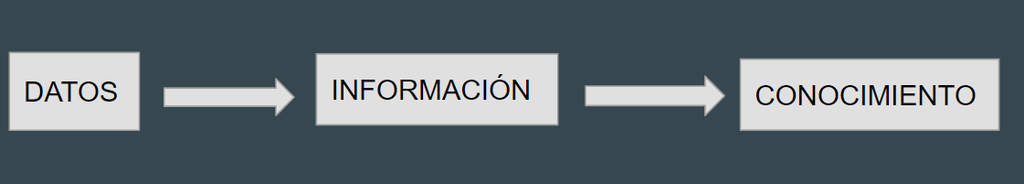

## Ciencia de datos: Un camino con los datos

- El alto nivel de producción de datos también es una OPORTUNIDAD.
- Definiendo Ciencia de Datos: - Extraer y generar conocimiento desde los datos.
- Física, Biología, Química, todas son ciencias que estudian el sistema propio de cada cual.
- La ciencia de datos, tiene a los datos como objeto de estudio.

## Ciencia de Datos: Un camino con los datos

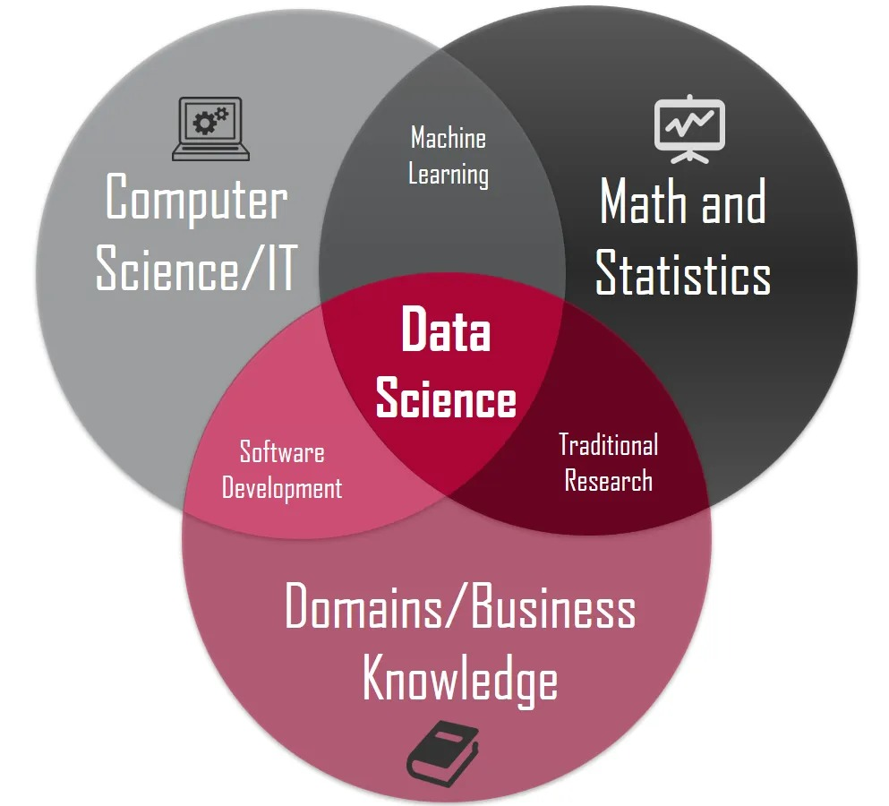

- [What is Data Science?](https://medium.com/data-science-in-2019/what-is-data-science-87e9dc225cf9)

## Objetivos en la ciencia de datos

- Uso de datos
- Métodos
- RESPONDER PREGUNTAS

## Las cinco V

- **VELOCIDAD**: La rapidez en el procesamiento y análisis de datos.
- **VARIEDAD**: El uso de datos desde diferentes formatos. Excluir las dificultades.
- **VALOR**: Desarrollo e impacto del uso de los datos.
- **VERACIDAD**: Calidad y validez de los datos.
- **VOLUMEN**: El uso de datos masivos desde diferentes fuentes.

## Ejemplos

[figure not shown]

## Ejemplos

[figure not shown]

## Ejemplos

- Se usaron datos del padrón electoral
- Datos censales
- Datos de nivel socioeconómico
- Análisis de redes, econometría, trabajo de análisis con texto.

## Ejemplos

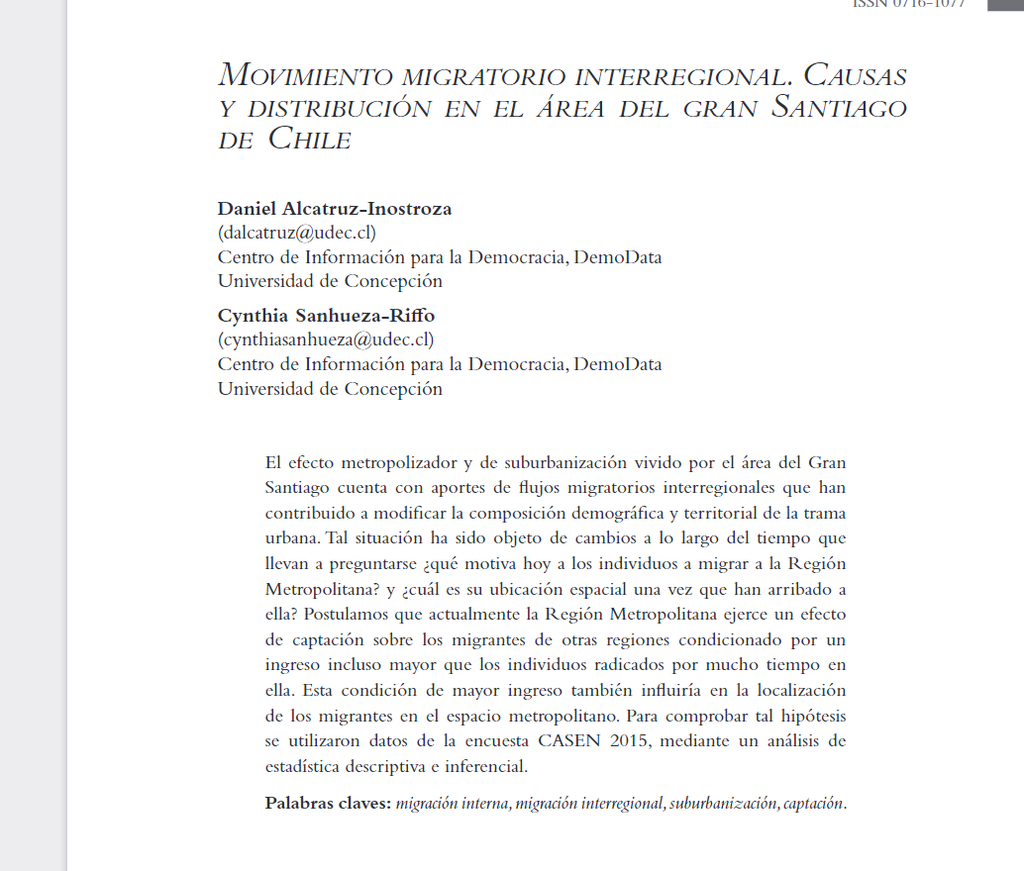

## Ejemplos

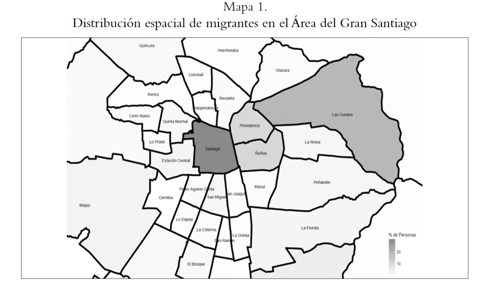

## Ejemplos

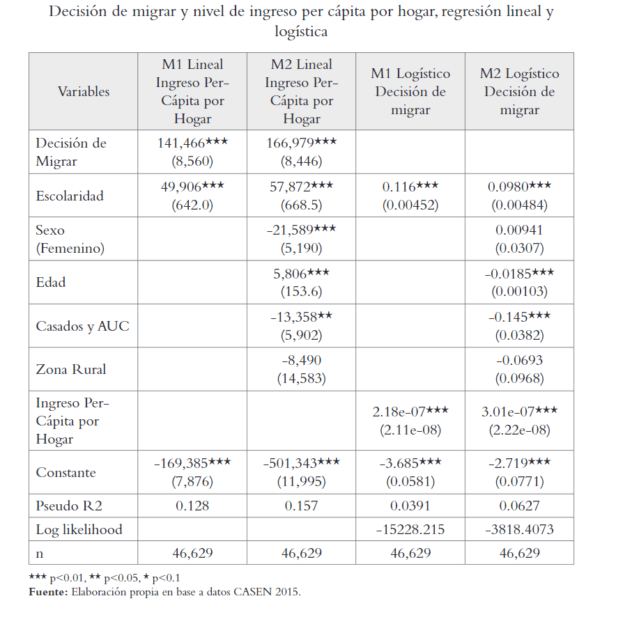

## Ciencia de Datos: Relevancias

- La relevancia de la ciencia de datos surge por la gran disposición de datos. (Volumen)
- Múltiples métodos y algoritmos.
- Amplia disponibilidad de software para el desarrollo y procesamiento.
- Las dificultades de almacenamiento y procesamiento han ido decreciendo.

## Harvard Bussiness Review: Data Scientist

*“The sexiest for in the 21th century….”*

## Y cómo incorporar la ciencia de datos a nuestro trabajo?

En este curso:

- Fundamentos de la ciencia de datos
- Procesar y analizar datos
- Generar y trazar estrategias para trabajar con nuestros datos
- Aprendizaje de métodos desde la estadística y la computación
- Machine learning -Visualización de datos

*…antes… no basta con saber programar y procesar datos, la mitad del trabajo es antes… durante… después…*

## Procesamiento de datos:

Algunas consideraciones importantes:

- **Curiosidad**: Motivación por “explorar” los datos, innovar frente a problemas. No todo es explícito.
- **Dominio**: El aporte que queremos generar debe basarse en conocimiento científico. Recordar el atributo de VERACIDAD.
- **Argumentación**: Las respuestas generadas desde nuestros análisis deben proceder desde el uso de métodos adecuados y una buena interpretación de los resultados. Manejar nuestras hipótesis.

## Procesamiento de datos:

- **Dominio de plataformas**: Aún cuando la experticia sobre códigos y herramientas, es necesario tener cierta versatilidad para manejar diferentes plataformas para diferentes problemas.
- **Comunicar resultados**: Saber contar una historia. Se requieren preguntas e hipótesis que podamos demostrar mediante la visualización de datos.

¿Tod@s tenemos estas características?

## Sistemas Cloud

- Los sistemas físicos de cómputo cada día presentan más problemas
- Dropbox, Drive, ICloud. etc
- La virtud está en que la “nube”, es algo más que el almacenamiento
- Poder de almacenamiento y poder de cómputo.

## High Performance Computing

- Ejecutar cálculos de manera sincronizada en una gran cantidad de computadoras en red
- HPC permite ejecutar cálculos que son demasiado grandes para las computadoras normales, lo que reduce el tiempo que lleva completar operaciones grandes
- HPC permite la simulación o el análisis de grandes volúmenes de datos que, de otro modo, sería imposible hacer con computadoras estándar

## Clusteres y supercomputadores

- Una sola computadora de alto rendimiento se compone de un grupo de computadoras llamado clúster.
- Cada nodo tiene un sistema operativo que consta de un procesador con múltiples núcleos, almacenamiento y capacidades de red que permiten que los nodos se comuniquen entre sí.

*nodo*: computador

## Ejemplo

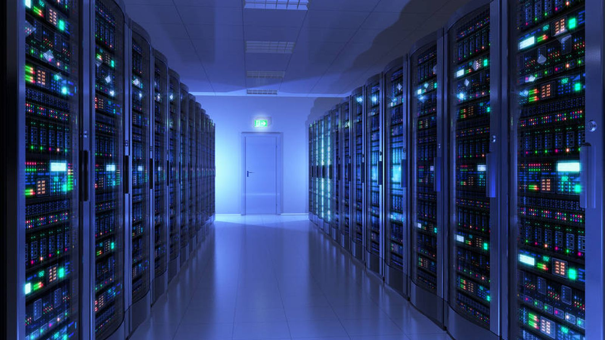

- 16 nodos

- 4 núcleos por procesador
- red

*Sistema de alto rendimiento computacional*

## Clouds disponibles

- Amazon
- DigitalOcean
- Microsoft Azure
- Google Cloud Platform

## Algunas ventajas del trabajo en clouding:

- Cargar algoritmos necesarios para el análisis de volúmenes gigantes de información.
- Utilización de máquinas virtuales.
- MULTIAGENTES, esto es, la posibilidad de desarrollar varias tareas al mismo tiempo.

## Y cómo hacemos ciencia de datos?

[figure not shown]